# CSCI E-63C: Final Exam/Project

## Load Libraries and Preprocess Data

```r
library(ggplot2)
library(GGally)
library(gridExtra)
library(MASS)
library(glmnet)
library(randomForest)
library(reshape2)
library(e1071)
# function to analyze the success rate by category
success.rate.by.level <- function(column){
    lvls <- levels(column)
    total <- length(column)
    counts <- numeric()
    rates <- numeric()
    Ycounts <- numeric()
    Yrates <- numeric()
    i <- 1
    for (l in 1:length(lvls)){
        counts[i] <- nrow(raw.data[column == lvls[l],])
        rates[i] <- 100 * (counts[i] / total)
        Ycounts[i] <- nrow(raw.data[column == lvls[l] & raw.data$response == "Y",])
        Yrates[i] <- 100 * (Ycounts[i] / counts[i])
        i <- i + 1
    }
    result <- as.data.frame(cbind(counts, rates, Ycounts, Yrates))
    result <- cbind(lvls, result)
    result <- result[order(Yrates),]
    result[,1] <- factor(result[,1], levels = result[,1])
    return(result)
}

# read in the raw training data
raw.data <- read.csv("final-data-train.csv")

# make the id column the row names and remove it as a variable
pp.data.1 <- raw.data
rownames(pp.data.1) <- pp.data.1$id
pp.data.1$id <- NULL

# remove non-relevant variables
pp.data.1$ent <- NULL
pp.data.1$ox <- NULL
pp.data.1$bnf <- NULL

# wc: combine a/c/f; combine b/e; make 3 levels
pp.data.1$wc <- as.character(pp.data.1$wc)
pp.data.1$wc[pp.data.1$wc == "a" | pp.data.1$wc == "c" | pp.data.1$wc == "f"] <- "acf"
pp.data.1$wc[pp.data.1$wc != "acf" & pp.data.1$wc != "d"] <- "be"
pp.data.1$wc <- as.factor(pp.data.1$wc)

# zwp: combine S/R; combine T/O/U/N; combine V/X/W/Q/Y/P/Z; make 3 levels
pp.data.1$zwp <- as.character(pp.data.1$zwp)
pp.data.1$zwp[pp.data.1$zwp == "S" | pp.data.1$zwp == "R"] <- "SR"
pp.data.1$zwp[pp.data.1$zwp == "T" | pp.data.1$zwp == "O" | pp.data.1$zwp == "U" | pp.data.1$zwp == "N"] <- "TOUN"
pp.data.1$zwp[pp.data.1$zwp != "SR" & pp.data.1$zwp != "TOUN"] <- "VXWQYPZ"
pp.data.1$zwp <- as.factor(pp.data.1$zwp)

# ypz: combine 1/4/11/0/6/14/7; combine 3/12/10; combine 15/19/16; combine 17/13/5/8/2; make 4 levels
pp.data.1$ypz <- as.character(pp.data.1$ypz)
pp.data.1$ypz[pp.data.1$ypz == "3" | pp.data.1$ypz == "12"| pp.data.1$ypz == "10"] <- "3,12,10"
pp.data.1$ypz[pp.data.1$ypz == "15" | pp.data.1$ypz == "19"| pp.data.1$ypz == "16"] <- "15,19,16"
pp.data.1$ypz[pp.data.1$ypz == "17" | pp.data.1$ypz == "13"| pp.data.1$ypz == "5" | pp.data.1$ypz == "8"| pp.data.1$ypz == "2"] <- "17,13,5,8,2"
pp.data.1$ypz[pp.data.1$ypz != "3,12,10" & pp.data.1$ypz != "3,12,10" & pp.data.1$ypz != "17,13,5,8,2"] <- "1,4,11,0,6,14,7"
pp.data.1$ypz <- as.factor(pp.data.1$ypz)

#combine sb into s2/s5 and not s2/s5
pp.data.1$sb <- as.character(pp.data.1$sb)
pp.data.1$sb[(pp.data.1$sb == "s2") | (pp.data.1$sb == "s5")] <- "s2s5"
pp.data.1$sb[pp.data.1$sb != "s2s5"] <- "s1s3s4s6s7s8"
pp.data.1$sb <- as.factor(pp.data.1$sb)

# xt: combine dgk/ntb/fcc; combine mrm/gcn; make 2 levels
pp.data.1$xt <- as.character(pp.data.1$xt)
pp.data.1$xt[(pp.data.1$xt == "mrm") | (pp.data.1$xt == "gcn")] <- "mrm,gcn"
pp.data.1$xt[pp.data.1$xt != "mrm,gcn"] <- "dgk,ntb,fcc"
pp.data.1$xt <- as.factor(pp.data.1$xt)

# ku: create ordered factors to treat ku as continuous
rates.ku <- success.rate.by.level(raw.data$ku)
pp.data.1$ku <- factor(pp.data.1$ku, levels = rates.ku[,1])
pp.data.1$ku <- as.numeric(pp.data.1$ku)

#rearrange to continuous and discrete
continuous.vec <- c("response", "dtj", "qh", "sci", "bw", "ku", "is")
discrete.list <- list(
    "wc",
    "zwp",
    "wi",
    "ypz",
    "tdt",
    "sb",
    "xt",
    "np"
)
discrete.vec <- c("response", unlist(discrete.list, use.names = FALSE))
colorder <- c(continuous.vec, discrete.vec[2:length(discrete.vec)])
pp.data.1 <- pp.data.1[,colorder]

#subset data for testing models
sampled.rows <- sample(seq(1, nrow(pp.data.1)),ceiling(0.2*nrow(pp.data.1)),replace = FALSE)
model.test.data <- pp.data.1[sampled.rows,]

#subset data for testing code
xs.sampled.rows <- sample(seq(1, nrow(pp.data.1)),ceiling(1/31*nrow(pp.data.1)),replace = FALSE)
xs.model.test.data <- pp.data.1[xs.sampled.rows,]

#dropped variables from variable selection analysis
select.data <- pp.data.1
select.data$sci <- NULL
select.data$bw <- NULL
select.data$ypz <- NULL
head(select.data)
```

```
##        response     dtj       qh ku      is wc     zwp  wi tdt   sb          xt
## 165931        N 3.31662 1.619306  2 0.24077  d      SR gnq  kc s2s5 dgk,ntb,fcc
## 241964        N 0.00000 1.465870  8 3.76180 be      SR gmz  sm s2s5 dgk,ntb,fcc
## 387089        Y 3.46410 2.011248  4 2.49990 be    TOUN gmz  zp s2s5 dgk,ntb,fcc
## 433922        Y 3.31662 1.915616  3 2.47710 be VXWQYPZ gmz  sm s2s5 dgk,ntb,fcc
## 175120        N 3.74166 1.740224  1 4.17080 be      SR gmz  zp s2s5 dgk,ntb,fcc
## 353214        N 2.23607 1.656426  1 2.94250 be      SR gmz  zp s2s5 dgk,ntb,fcc
##        np
## 165931  j
## 241964  j
## 387089  j
## 433922  k
## 175120  j
## 353214  j
```

```r
# csv's for previous model performance:
logistic.performance.2 <- read.csv("logistic_performance.csv")
lda.performance.2 <- read.csv("lda_performance.csv")
rf.performance.2 <- read.csv("rf_performance.csv")
compare.table2.2 <- read.csv("compare_err_table.csv")
```

# Problem 5: SVM (20 points)

Develop SVM model of categorical outcome `response` deciding on the choice of kernel, cost, etc. that appear to yield better performance. Test model performance on multiple splits of data into training and test subsets, summarize model performance in terms of accuracy/error/sensitivity/specificity and compare to the performance of the rest of the models developed above (logistic regression, LDA, random forest).

```r
svmfit <- svm(response~., data=select.data, kernel="linear", cost=.1, scale = TRUE)
svm.err.table <- table(predict(svmfit), select.data$response)
svm.err.table
```

```
##
##         N     Y
##   N 21947  2724
##   Y  1409  4914
```

```r
error.rate <- 100 * (1-sum(diag(svm.err.table))/sum(svm.err.table))
error.rate
```

```
## [1] 13.33484
```

```r
svmfit <- svm(response~., data=select.data, kernel="linear", cost=1, scale = TRUE)
svm.err.table <- table(predict(svmfit), select.data$response)
svm.err.table
```

```
##
##         N     Y
##   N 21947  2724
##   Y  1409  4914
```

```r
error.rate <- 100 * (1-sum(diag(svm.err.table))/sum(svm.err.table))
error.rate
```

```
## [1] 13.33484
```

```r
svmfit <- svm(response~., data=select.data, kernel="linear", cost=10, scale = TRUE)
svm.err.table <- table(predict(svmfit), select.data$response)
svm.err.table
```

```
##
##         N     Y
##   N 21947  2724
##   Y  1409  4914
```

```r
error.rate <- 100 * (1-sum(diag(svm.err.table))/sum(svm.err.table))
error.rate
```

```
## [1] 13.33484
```

```r
svmfit <- svm(response~., data=select.data, kernel="linear", cost=.01, scale = TRUE)
svm.err.table <- table(predict(svmfit), select.data$response)
svm.err.table
```

```
##
##         N     Y
##   N 22010  2853
##   Y  1346  4785
```

```r
error.rate <- 100 * (1-sum(diag(svm.err.table))/sum(svm.err.table))
error.rate
```

```
## [1] 13.54778
```

I picked cost=1 because it generated the same error rate as higher cost models but in less time and is therefore less expensive.

```r
svmfit <- svm(response~., data=select.data, kernel="radial", cost=1, gamma=.1,
              scale = TRUE)
svm.err.table <- table(predict(svmfit), select.data$response)
svm.err.table
```

```
##
##         N     Y
##   N 22139  2161
##   Y  1217  5477
```

```r
error.rate <- 100 * (1-sum(diag(svm.err.table))/sum(svm.err.table))
error.rate
```

```
## [1] 10.89888
```

```r
svmfit <- svm(response~., data=select.data, kernel="radial", cost=1, gamma=1,
              scale = TRUE)
svm.err.table <- table(predict(svmfit), select.data$response)
svm.err.table
```

```
##
##         N     Y
##   N 22415  1592
##   Y   941  6046
```

```r
error.rate <- 100 * (1-sum(diag(svm.err.table))/sum(svm.err.table))
error.rate
```

```
## [1] 8.17255
```

```r
svmfit <- svm(response~., data=select.data, kernel="radial", cost=1, gamma=10,
              scale = TRUE)
svm.err.table <- table(predict(svmfit), select.data$response)
svm.err.table
```

```
##
##         N     Y
##   N 23302  1000
##   Y    54  6638
```

```r
error.rate <- 100 * (1-sum(diag(svm.err.table))/sum(svm.err.table))
error.rate
```

```
## [1] 3.400658
```

The radial kernel has better results but looks more prone to overfitting. I will choose the radial kernel with a model choice of the gamma value = 1.

```r
#set parameters
iterations <- 10
gamma <- 1
cost <- 1
kernel <- "radial"

#create storage
error.rate = numeric()
accuracy = numeric()
sensitivity = numeric()
specificity = numeric()

#train/test loop
for (i in 1:iterations){

    #split into test/train
    test.row.sample <- sample(seq(1,nrow(select.data)),
                              ceiling(.3 * nrow(select.data)),
                              replace = FALSE)
    test.split <- select.data[test.row.sample,]
    train.split <- select.data[-test.row.sample,]

    #fit and predict svm model
    svmfit <- svm(response~., data=train.split,
                  kernel=kernel,
                  cost=cost,
                  gamma=gamma,
                  scale = TRUE)
    predicted <- predict(svmfit, test.split)

    #computing performance of the model
    truth <- as.numeric(test.split$response) - 1
    predicted.num <- as.numeric(predicted) - 1
    svm.err.table <- table(predicted, test.split$response)
    TP = sum(truth==1 & predicted.num==1)
    TN = sum(truth==0 & predicted.num==0)
    FP = sum(truth==0 & predicted.num==1)
    FN = sum(truth==1 & predicted.num==0)
    P = TP+FN
    N = FP+TN
    error.rate[i] <- 100 * (1-sum(diag(svm.err.table))/sum(svm.err.table))
    accuracy[i] <- 100 - error.rate[i]
    sensitivity[i] <- signif(100*TP/P,3)
    specificity[i] <- signif(100*TN/N,3)
}

# results
svm.performance <- cbind(error.rate, accuracy, sensitivity, specificity)
svm.performance.mean <- as.data.frame(apply(svm.performance, 2, mean))
colnames(svm.performance.mean) <- paste0(iterations, "rep.svm.mean")
```

```r
head(svm.performance)
```

```
##      error.rate accuracy sensitivity specificity
## [1,]   11.21626 88.78374        72.9        94.1
## [2,]   10.91515 89.08485        73.6        94.1
## [3,]   10.91515 89.08485        73.4        94.4
## [4,]   11.38832 88.61168        72.7        93.7
## [5,]   10.99043 89.00957        72.4        94.2
## [6,]   10.97968 89.02032        73.2        94.1
```

```r
svm.performance.mean
```

```
##             10rep.svm.mean
## error.rate        10.98613
## accuracy          89.01387
## sensitivity       73.47000
## specificity       94.09000
```

```r
final.compare.table <- cbind(compare.table2.2[,2:ncol(compare.table2.2)], svm.performance.mean)
final.compare.table
```

```
##             X500rep.logistic.mean X500rep.lda.mean X20rep.rf.mean
## error.rate                11.6598          12.3006       10.92214
## accuracy                  88.3402          87.6994       89.07786
## sensitivity               65.5644          61.8742       74.41000
## specificity               95.7778          96.1428       93.88000
##             10rep.svm.mean
## error.rate        10.98613
## accuracy          89.01387
## sensitivity       73.47000
## specificity       94.09000
```

# Problem 6: predictions for test dataset (10 points)

## Problem 6a: compare logistic regression, LDA, random forest and SVM model performance (3 points)

Compare performance of the models developed above (logistic regression, LDA, random forest, SVM) in terms of their accuracy, error and sensitivity/specificity. Comment on differences and similarities between them.

```r
colnames(final.compare.table) <- c("logistic","lda","rf","svm")
final.compare.table
```

```
##             logistic     lda       rf      svm
## error.rate   11.6598 12.3006 10.92214 10.98613
## accuracy     88.3402 87.6994 89.07786 89.01387
## sensitivity  65.5644 61.8742 74.41000 73.47000
## specificity  95.7778 96.1428 93.88000 94.09000
```

```r
#split logistic regression performance data for plotting
log.err <- cbind(rep("logistic",nrow(logistic.performance.2)),
  logistic.performance.2[,1])
log.acc <- cbind(rep("logistic",nrow(logistic.performance.2)),
  logistic.performance.2[,2])
log.sens <- cbind(rep("logistic",nrow(logistic.performance.2)),
  logistic.performance.2[,3])
log.spec <- cbind(rep("logistic",nrow(logistic.performance.2)),
  logistic.performance.2[,4])

#split lda regression performance data for plotting
lda.err <- cbind(rep("lda",nrow(lda.performance.2)),
  lda.performance.2[,1])
lda.acc <- cbind(rep("lda",nrow(lda.performance.2)),
  lda.performance.2[,2])
lda.sens <- cbind(rep("lda",nrow(lda.performance.2)),
  lda.performance.2[,3])
lda.spec <- cbind(rep("lda",nrow(lda.performance.2)),
  lda.performance.2[,4])

#split rf regression performance data for plotting
rf.err <- cbind(rep("rf",nrow(rf.performance.2)),
  rf.performance.2[,1])
rf.acc <- cbind(rep("rf",nrow(rf.performance.2)),
  rf.performance.2[,2])
rf.sens <- cbind(rep("rf",nrow(rf.performance.2)),
  rf.performance.2[,3])
rf.spec <- cbind(rep("rf",nrow(rf.performance.2)),
  rf.performance.2[,4])

#split svm regression performance data for plotting
svm.err <- cbind(rep("svm",nrow(svm.performance)),
  svm.performance[,1])
svm.acc <- cbind(rep("svm",nrow(svm.performance)),
  svm.performance[,2])
svm.sens <- cbind(rep("svm",nrow(svm.performance)),
  svm.performance[,3])
svm.spec <- cbind(rep("svm",nrow(svm.performance)),
  svm.performance[,4])

#bind for plotting
err <- as.data.frame(rbind(log.err, lda.err, rf.err, svm.err))
colnames(err) <- c("model", "error")
acc <- as.data.frame(rbind(log.acc, lda.acc, rf.acc, svm.acc))
colnames(acc) <- c("model", "accuracy")
sens <- as.data.frame(rbind(log.sens, lda.sens, rf.sens, svm.sens))
colnames(sens) <- c("model", "sensitivity")
spec <- as.data.frame(rbind(log.spec, lda.spec, rf.spec, svm.spec))
colnames(spec) <- c("model", "specificity")
```

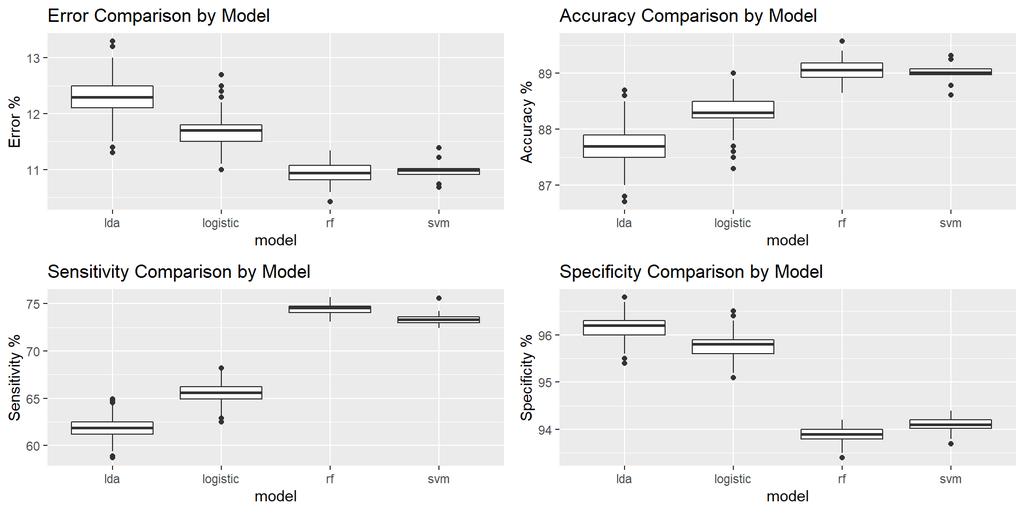

```r
#plot
a <- ggplot(err, aes(x=model, y=as.numeric(as.character(error)))) +
  geom_boxplot() +
  ggtitle("Error Comparison by Model") +
  ylab("Error %")

b <- ggplot(acc, aes(x=model, y=as.numeric(as.character(accuracy)))) +
  geom_boxplot() +
  ggtitle("Accuracy Comparison by Model") +
  ylab("Accuracy %")

c <- ggplot(sens, aes(x=model, y=as.numeric(as.character(sensitivity)))) +
  geom_boxplot() +
  ggtitle("Sensitivity Comparison by Model") +
  ylab("Sensitivity %")

d <- ggplot(spec, aes(x=model, y=as.numeric(as.character(specificity)))) +
  geom_boxplot() +
  ggtitle("Specificity Comparison by Model") +
  ylab("Specificity %")

grid.arrange(a, b, c, d, ncol = 2)
```

Given that his final exam is indicating lowest error and highest accuracy, I choose the random forest because of its high accuracy, low error and tight and stable quantiles across all four metrics. As an added bonus it also has the highest sensitivity which could be beneficial considering in the training data there were much fewer Y’s than N’s. Discerning the fewer Y’s can add value to the model.

```r
final.compare.table
```

```
##             logistic     lda       rf      svm
## error.rate   11.6598 12.3006 10.92214 10.98613
## accuracy     88.3402 87.6994 89.07786 89.01387
## sensitivity  65.5644 61.8742 74.41000 73.47000
## specificity  95.7778 96.1428 93.88000 94.09000
```

## Problem 6b: make predictions for the **test** dataset (3 points)

Decide on the model that performs the best and use it to make predictions for the **test** dataset. This is the dataset that is provided separately from training data without the outcome `response` that we are modeling here. Upload resulting predictions in comma-separated values (CSV) format into the Canvas website. Please check sample files with test dataset predictions for the expected format of the *.csv file with predictions: your submission must be in precisely the same format – two and only two columns, first column - ids of the test observations (“id” column in test dataset), second - predictions as Y/N calls (not 0/1, 1/2, true/false, etc.). The name of the second column of predictions is what will be used in leaderboard as its name.

```r
# function to analyze the success rate by category
success.rate.by.level <- function(column){
    lvls <- levels(column)
    total <- length(column)
    counts <- numeric()
    rates <- numeric()
    Ycounts <- numeric()
    Yrates <- numeric()
    i <- 1
    for (l in 1:length(lvls)){
        counts[i] <- nrow(final.test.data[column == lvls[l],])
        rates[i] <- 100 * (counts[i] / total)
        Ycounts[i] <- nrow(final.test.data[column == lvls[l] & final.test.data$response == "Y",])
        Yrates[i] <- 100 * (Ycounts[i] / counts[i])
        i <- i + 1
    }
    result <- as.data.frame(cbind(counts, rates, Ycounts, Yrates))
    result <- cbind(lvls, result)
    result <- result[order(Yrates),]
    result[,1] <- factor(result[,1], levels = result[,1])
    return(result)
}

#load raw data
final.test.data <- read.csv("final-data-test.csv")

# make the id column the row names and remove it as a variable
pp.data.1 <- final.test.data
rownames(pp.data.1) <- pp.data.1$id
pp.data.1$id <- NULL

# remove non-relevant variables
pp.data.1$ent <- NULL
pp.data.1$ox <- NULL
pp.data.1$bnf <- NULL

# wc: combine a/c/f; combine b/e; make 3 levels
pp.data.1$wc <- as.character(pp.data.1$wc)
pp.data.1$wc[pp.data.1$wc == "a" | pp.data.1$wc == "c" | pp.data.1$wc == "f"] <- "acf"
pp.data.1$wc[pp.data.1$wc != "acf" & pp.data.1$wc != "d"] <- "be"
pp.data.1$wc <- as.factor(pp.data.1$wc)

# zwp: combine S/R; combine T/O/U/N; combine V/X/W/Q/Y/P/Z; make 3 levels
pp.data.1$zwp <- as.character(pp.data.1$zwp)
pp.data.1$zwp[pp.data.1$zwp == "S" | pp.data.1$zwp == "R"] <- "SR"
pp.data.1$zwp[pp.data.1$zwp == "T" | pp.data.1$zwp == "O" | pp.data.1$zwp == "U" | pp.data.1$zwp == "N"] <- "TOUN"
pp.data.1$zwp[pp.data.1$zwp != "SR" & pp.data.1$zwp != "TOUN"] <- "VXWQYPZ"
pp.data.1$zwp <- as.factor(pp.data.1$zwp)

# ypz: combine 1/4/11/0/6/14/7; combine 3/12/10; combine 15/19/16; combine 17/13/5/8/2; make 4 levels
pp.data.1$ypz <- as.character(pp.data.1$ypz)
pp.data.1$ypz[pp.data.1$ypz == "3" | pp.data.1$ypz == "12"| pp.data.1$ypz == "10"] <- "3,12,10"
pp.data.1$ypz[pp.data.1$ypz == "15" | pp.data.1$ypz == "19"| pp.data.1$ypz == "16"] <- "15,19,16"
pp.data.1$ypz[pp.data.1$ypz == "17" | pp.data.1$ypz == "13"| pp.data.1$ypz == "5" | pp.data.1$ypz == "8"| pp.data.1$ypz == "2"] <- "17,13,5,8,2"
pp.data.1$ypz[pp.data.1$ypz != "3,12,10" & pp.data.1$ypz != "3,12,10" & pp.data.1$ypz != "17,13,5,8,2"] <- "1,4,11,0,6,14,7"
pp.data.1$ypz <- as.factor(pp.data.1$ypz)

#combine sb into s2/s5 and not s2/s5
pp.data.1$sb <- as.character(pp.data.1$sb)
pp.data.1$sb[(pp.data.1$sb == "s2") | (pp.data.1$sb == "s5")] <- "s2s5"
pp.data.1$sb[pp.data.1$sb != "s2s5"] <- "s1s3s4s6s7s8"
pp.data.1$sb <- as.factor(pp.data.1$sb)

# xt: combine dgk/ntb/fcc; combine mrm/gcn; make 2 levels
pp.data.1$xt <- as.character(pp.data.1$xt)
pp.data.1$xt[(pp.data.1$xt == "mrm") | (pp.data.1$xt == "gcn")] <- "mrm,gcn"
pp.data.1$xt[pp.data.1$xt != "mrm,gcn"] <- "dgk,ntb,fcc"
pp.data.1$xt <- as.factor(pp.data.1$xt)

# ku: create ordered factors to treat ku as continuous
rates.ku <- success.rate.by.level(final.test.data$ku)
pp.data.1$ku <- factor(pp.data.1$ku, levels = rates.ku[,1])
pp.data.1$ku <- as.numeric(pp.data.1$ku)

#rearrange to continuous and discrete
continuous.vec <- c("dtj", "qh", "sci", "bw", "ku", "is")
discrete.list <- list(
    "wc",
    "zwp",
    "wi",
    "ypz",
    "tdt",
    "sb",
    "xt",
    "np"
)
discrete.vec <- unlist(discrete.list, use.names = FALSE)
colorder <- c(continuous.vec, discrete.vec)
pp.data.1 <- pp.data.1[,colorder]

#dropped variables from variable selection analysis
select.test.data <- pp.data.1
select.test.data$sci <- NULL
select.test.data$bw <- NULL
select.test.data$ypz <- NULL
head(select.test.data)
```

```
##            dtj       qh ku        is wc  zwp  wi tdt           sb          xt
## 151991 2.64575 1.639270  8 2.3139000 be TOUN gmz  zp         s2s5 dgk,ntb,fcc
## 24044  2.82843 1.614754  8 0.6308300 be TOUN gmz  kc         s2s5 dgk,ntb,fcc
## 346885 3.31662 2.079449  5 0.0038861  d TOUN gmz  sm s1s3s4s6s7s8 dgk,ntb,fcc
## 274171 2.64575 1.535822  7 1.4317000 be   SR gmz  kc         s2s5 dgk,ntb,fcc
## 211385 3.31662 2.051050  8 1.0200000 be TOUN gmz  sm         s2s5 dgk,ntb,fcc
## 356033 2.82843 1.639731  6 0.9845000 be TOUN gmz  sm         s2s5 dgk,ntb,fcc
##        np
## 151991  j
## 24044   j
## 346885  k
## 274171  k
## 211385  j
## 356033  j
```

```r
rfRes <- randomForest(select.data[,2:ncol(select.data)],
                      select.data$response,
                      mtry = 5, ntree = 1000)
final.prediction <- predict(rfRes, newdata=select.test.data)
head(final.prediction)
```

```
## 151991  24044 346885 274171 211385 356033
##      N      N      Y      N      Y      N
## Levels: N Y
```

```r
write.csv(final.prediction, "final_prediction_knapp_stephen.csv")
```

## Problem 6c: get better than coin flip by 10% (4 points)

This is not really a problem *per se* but rather a criterion that we will go by when assessing quality of your predictions for the test dataset. You get these four points if your predictions for **test** dataset are better than those obtained from a fair coin flip (already shown in leaderboard and as examples of the file format for predictions upload) by at least 10% on **all** four metrics shown in the leaderboard (accuracy, sensitivity, specificity and precision). But then predictions by the coin flip should not be very difficult to improve upon.